# Assignment 9: Predicting Graduate School Admission

Jacob Janke

2026-04-20

### 0.0.1 Introduction

The goal of this assignment is to determine which applicant characteristics are associated with graduate school admission. The outcome variable is **admit** (1 = admitted, 0 = not admitted). Predictors include:

- **gre**: GRE score
- **gpa**: Undergraduate GPA
- **rank**: Undergraduate institution rank (1 = highest tier, 4 = lowest tier)

I perform exploratory data analysis (EDA), clean and prepare the data, fit logistic regression models, evaluate model performance, and interpret results in terms of odds ratios.

### 0.0.2 Data Loading and Cleaning

```r
# Use a relative path from Assignments/Assignment_9 to Data/
admissions_raw <- read_csv("../../Data/GradSchool_Admissions.csv", show_col_types = FALSE)

# Initial structure
str(admissions_raw)
```

```
## spc_tbl_ [400 × 4] (S3: spec_tbl_df/tbl_df/tbl/data.frame)
##  $ admit: num [1:400] 0 1 1 1 0 1 1 0 1 0 ...
##  $ gre  : num [1:400] 380 660 800 640 520 760 560 400 540 700 ...
##  $ gpa  : num [1:400] 3.61 3.67 4 3.19 2.93 3 2.98 3.08 3.39 3.92 ...
##  $ rank : num [1:400] 3 3 1 4 4 2 1 2 3 2 ...
##  - attr(*, "spec")=
##   .. cols(
##   ..   admit = col_double(),
##   ..   gre = col_double(),
##   ..   gpa = col_double(),
##   ..   rank = col_double()
##   .. )
##  - attr(*, "problems")=<externalptr>
```

```r
# Cleaned analysis dataset
admissions <- admissions_raw %>%
  mutate(
    admit = as.integer(admit),
    admit_factor = factor(admit, levels = c(0, 1), labels = c("Not Admitted", "Admitted")),
    rank = factor(rank, levels = c(1, 2, 3, 4), ordered = TRUE)
  )

# Data quality checks
missing_summary <- colSums(is.na(admissions))
duplicate_rows <- sum(duplicated(admissions_raw))

missing_summary
```

```
##        admit          gre          gpa         rank admit_factor
##            0            0            0            0            0
```

```r
duplicate_rows
```

```
## [1] 5
```

```r
# Basic range checks
admissions %>%
  summarise(
    min_gre = min(gre),
    max_gre = max(gre),
    min_gpa = min(gpa),
    max_gpa = max(gpa)
  )
```

```
## # A tibble: 1 × 4
##   min_gre max_gre min_gpa max_gpa
##     <dbl>   <dbl>   <dbl>   <dbl>
## 1     220     800    2.26       4
```

### 0.0.3 Exploratory Data Analysis

#### 0.0.3.1 Summary Statistics

```r
summary(admissions)
```

```
##      admit             gre             gpa        rank          admit_factor
##  Min.   :0.0000   Min.   :220.0   Min.   :2.260   1: 61   Not Admitted:273
##  1st Qu.:0.0000   1st Qu.:520.0   1st Qu.:3.130   2:151   Admitted    :127
##  Median :0.0000   Median :580.0   Median :3.395   3:121
##  Mean   :0.3175   Mean   :587.7   Mean   :3.390   4: 67
##  3rd Qu.:1.0000   3rd Qu.:660.0   3rd Qu.:3.670
##  Max.   :1.0000   Max.   :800.0   Max.   :4.000
```

```r
numeric_summary <- admissions %>%
  select(admit, gre, gpa) %>%
  summarise(
    across(
      everything(),
      list(
        mean = ~mean(.),
        sd = ~sd(.),
        min = ~min(.),
        q1 = ~quantile(., 0.25),
        median = ~median(.),
        q3 = ~quantile(., 0.75),
        max = ~max(.)
      ),
      .names = "{.col}_{.fn}"
    )
  )

kable(numeric_summary, digits = 3, caption = "Numeric summary statistics for admission outcome and predictors.")
```

Numeric summary statistics for admission outcome and predictors.

| admit_mean | admit_sd | admit_min | admit_q1 | admit_median | admit_q3 | admit_max | gre_mean | gre_sd | gre_min | gre_q1 | gre_median | gre_q3 | gre_max | gpa_mean | gpa_sd | gpa_min | gpa_q1 | gpa_median | gpa_q3 | gpa_max |
| --- | --- | --- | --- | --- | --- | --- | --- | --- | --- | --- | --- | --- | --- | --- | --- | --- | --- | --- | --- | --- |
| 0.318 | 0.466 | 0 | 0 | 0 | 1 | 1 | 587.7 | 115.517 | 220 | 520 | 580 | 660 | 800 | 3.39 | 0.381 | 2.26 | 3.13 | 3.395 | 3.67 | 4 |

```r
rank_counts <- admissions %>% count(rank, name = "n")
kable(rank_counts, caption = "Counts by undergraduate institution rank.")
```

Counts by undergraduate institution rank.

| rank | n |
| --- | --- |
| 1 | 61 |
| 2 | 151 |
| 3 | 121 |
| 4 | 67 |

#### 0.0.3.2 Predictor Distributions

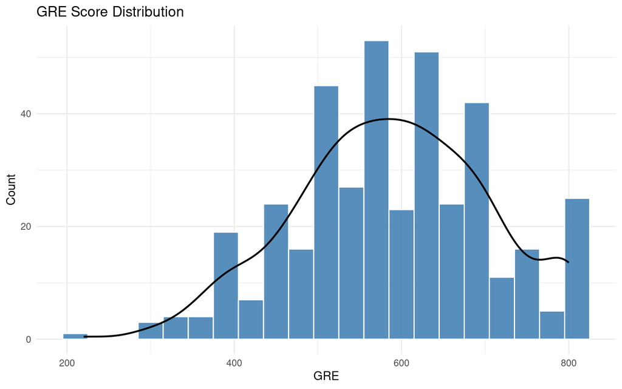

Distribution of GRE scores.

```r
ggplot(admissions, aes(x = gre)) +
  geom_histogram(binwidth = 30, fill = "steelblue", color = "white", alpha = 0.9) +
  geom_density(aes(y = after_stat(count * 30)), color = "black", linewidth = 0.8) +
  labs(title = "GRE Score Distribution", x = "GRE", y = "Count") +
  theme_minimal()
```

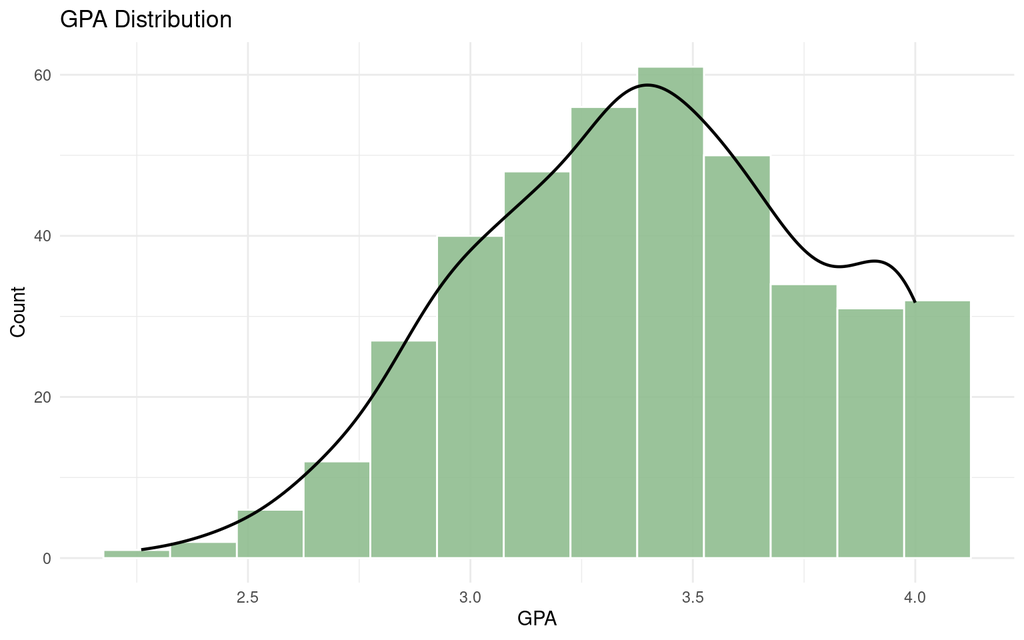

Distribution of GPA values.

```r
ggplot(admissions, aes(x = gpa)) +
  geom_histogram(binwidth = 0.15, fill = "darkseagreen", color = "white", alpha = 0.9) +
  geom_density(aes(y = after_stat(count * 0.15)), color = "black", linewidth = 0.8) +
  labs(title = "GPA Distribution", x = "GPA", y = "Count") +
  theme_minimal()
```

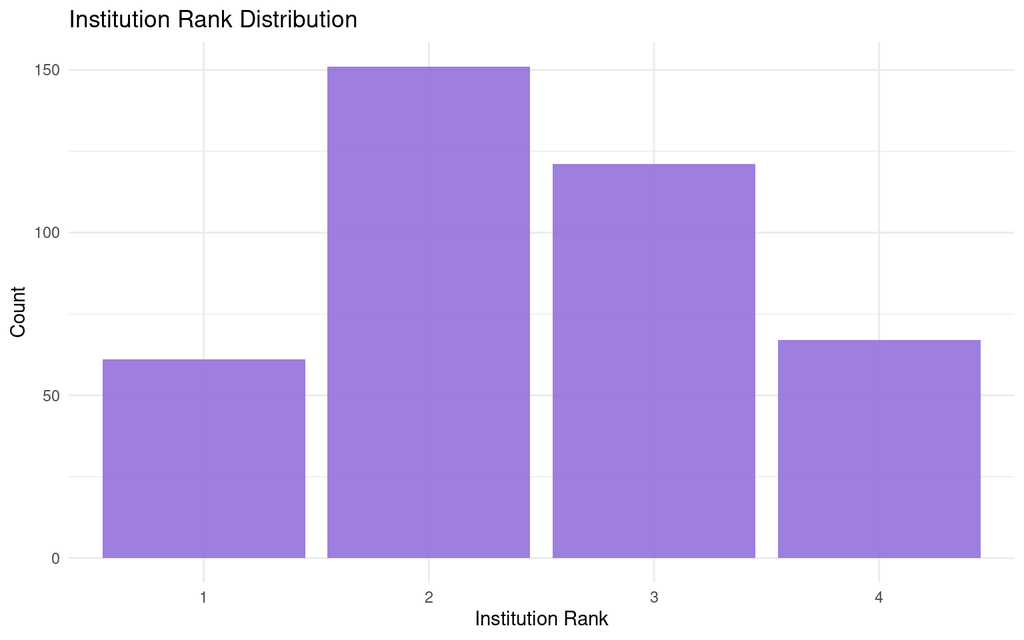

Distribution of undergraduate institution rank (1 = top tier).

```r
ggplot(admissions, aes(x = rank)) +
  geom_bar(fill = "mediumpurple", alpha = 0.9) +
  labs(title = "Institution Rank Distribution", x = "Institution Rank", y = "Count") +
  theme_minimal()
```

#### 0.0.3.3 Relationships Between Predictors and Admission

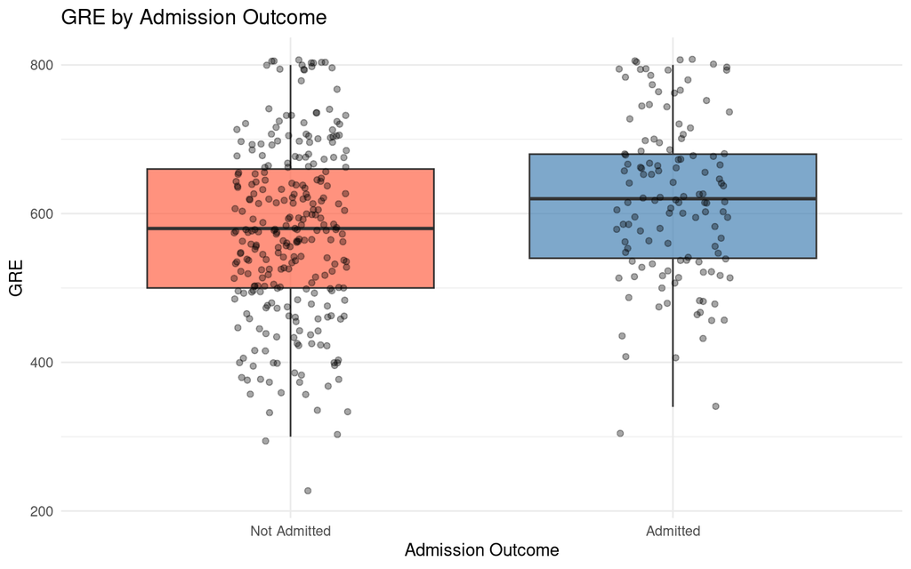

GRE by admission status with boxplot and jittered points.

```r
ggplot(admissions, aes(x = admit_factor, y = gre, fill = admit_factor)) +
  geom_boxplot(alpha = 0.7, outlier.shape = NA) +
  geom_jitter(width = 0.15, alpha = 0.35) +
  scale_fill_manual(values = c("tomato", "steelblue")) +
  labs(title = "GRE by Admission Outcome", x = "Admission Outcome", y = "GRE") +
  theme_minimal() +
  theme(legend.position = "none")
```

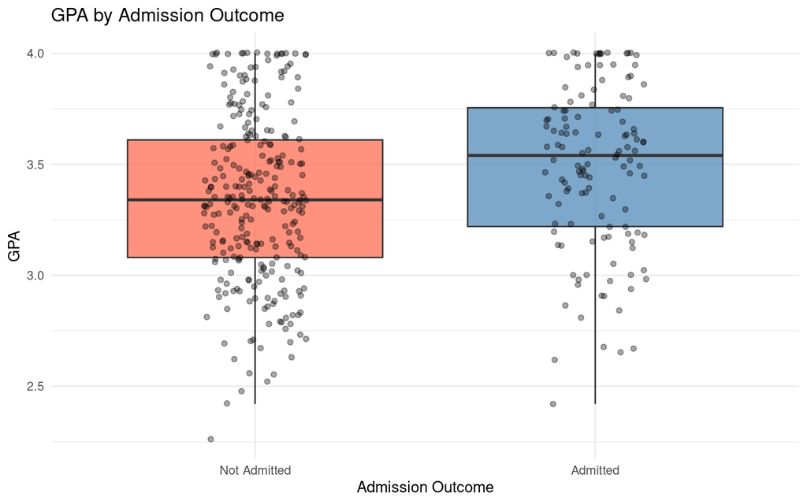

GPA by admission status with boxplot and jittered points.

```r
ggplot(admissions, aes(x = admit_factor, y = gpa, fill = admit_factor)) +
  geom_boxplot(alpha = 0.7, outlier.shape = NA) +
  geom_jitter(width = 0.15, alpha = 0.35) +
  scale_fill_manual(values = c("tomato", "steelblue")) +
  labs(title = "GPA by Admission Outcome", x = "Admission Outcome", y = "GPA") +
  theme_minimal() +
  theme(legend.position = "none")
```

```r
admit_by_rank <- admissions %>%
  group_by(rank) %>%
  summarise(admit_rate = mean(admit), n = n(), .groups = "drop")

kable(admit_by_rank, digits = 3, caption = "Observed admission rate by institution rank.")
```

Observed admission rate by institution rank.

| rank | admit_rate | n |
| --- | --- | --- |
| 1 | 0.541 | 61 |
| 2 | 0.358 | 151 |
| 3 | 0.231 | 121 |
| 4 | 0.179 | 67 |

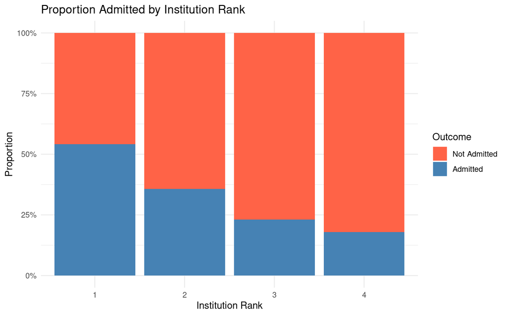

Admission rates by undergraduate institution rank.

```r
ggplot(admissions, aes(x = rank, fill = admit_factor)) +
  geom_bar(position = "fill") +
  scale_y_continuous(labels = scales::percent_format()) +
  scale_fill_manual(values = c("tomato", "steelblue")) +
  labs(
    title = "Proportion Admitted by Institution Rank",
    x = "Institution Rank",
    y = "Proportion",
    fill = "Outcome"
  ) +
  theme_minimal()
```

#### 0.0.3.4 Correlation Analysis

```r
corr_df <- admissions %>%
  mutate(rank_numeric = as.numeric(rank)) %>%
  select(admit, gre, gpa, rank_numeric)

corr_matrix <- cor(corr_df)
kable(round(corr_matrix, 3), caption = "Correlation matrix (Pearson).")
```

Correlation matrix (Pearson).

|  | admit | gre | gpa | rank_numeric |
| --- | --- | --- | --- | --- |
| admit | 1.000 | 0.184 | 0.178 | -0.243 |
| gre | 0.184 | 1.000 | 0.384 | -0.123 |
| gpa | 0.178 | 0.384 | 1.000 | -0.057 |
| rank_numeric | -0.243 | -0.123 | -0.057 | 1.000 |

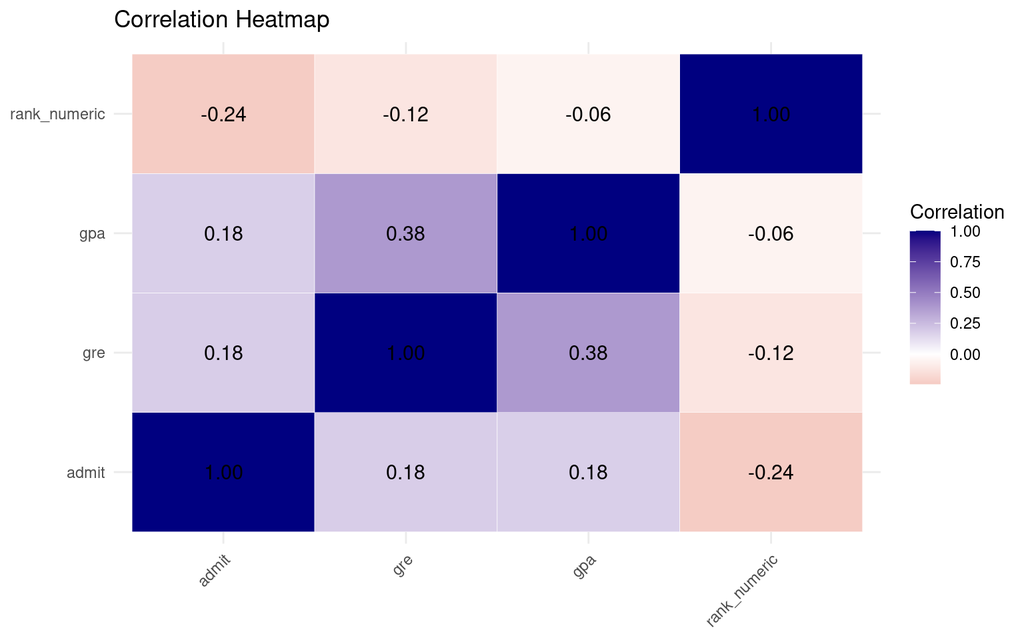

Correlation heatmap among numeric variables (rank converted to numeric for this analysis).

```r
corr_long <- as.data.frame(as.table(corr_matrix))
colnames(corr_long) <- c("Var1", "Var2", "Correlation")

ggplot(corr_long, aes(Var1, Var2, fill = Correlation)) +
  geom_tile(color = "white") +
  geom_text(aes(label = sprintf("%.2f", Correlation)), size = 4) +
  scale_fill_gradient2(low = "firebrick", mid = "white", high = "navy", midpoint = 0) +
  labs(title = "Correlation Heatmap", x = NULL, y = NULL) +
  theme_minimal() +
  theme(axis.text.x = element_text(angle = 45, hjust = 1))
```

### 0.0.4 Logistic Regression Modeling

#### 0.0.4.1 Fit Individual Predictor Models and Full Model

```r
# Logistic models
model_gre <- glm(admit ~ gre, data = admissions, family = binomial)
model_gpa <- glm(admit ~ gpa, data = admissions, family = binomial)
model_rank <- glm(admit ~ rank, data = admissions, family = binomial)
model_full <- glm(admit ~ gre + gpa + rank, data = admissions, family = binomial)
model_null <- glm(admit ~ 1, data = admissions, family = binomial)

summary(model_gre)
```

```
##
## Call:
## glm(formula = admit ~ gre, family = binomial, data = admissions)
##
## Deviance Residuals:
##     Min       1Q   Median       3Q      Max
## -1.1623  -0.9052  -0.7547   1.3486   1.9879
##
## Coefficients:
##              Estimate Std. Error z value Pr(>|z|)
## (Intercept) -2.901344   0.606038  -4.787 1.69e-06 ***
## gre          0.003582   0.000986   3.633  0.00028 ***
## ---
## Signif. codes:  0 '***' 0.001 '**' 0.01 '*' 0.05 '.' 0.1 ' ' 1
##
## (Dispersion parameter for binomial family taken to be 1)
##
##     Null deviance: 499.98  on 399  degrees of freedom
## Residual deviance: 486.06  on 398  degrees of freedom
## AIC: 490.06
##
## Number of Fisher Scoring iterations: 4
```

```r
summary(model_gpa)
```

```
##
## Call:
## glm(formula = admit ~ gpa, family = binomial, data = admissions)
##
## Deviance Residuals:
##     Min       1Q   Median       3Q      Max
## -1.1131  -0.8874  -0.7566   1.3305   1.9824
##
## Coefficients:
##             Estimate Std. Error z value Pr(>|z|)
## (Intercept)  -4.3576     1.0353  -4.209 2.57e-05 ***
## gpa           1.0511     0.2989   3.517 0.000437 ***
## ---
## Signif. codes:  0 '***' 0.001 '**' 0.01 '*' 0.05 '.' 0.1 ' ' 1
##
## (Dispersion parameter for binomial family taken to be 1)
##
##     Null deviance: 499.98  on 399  degrees of freedom
## Residual deviance: 486.97  on 398  degrees of freedom
## AIC: 490.97
##
## Number of Fisher Scoring iterations: 4
```

```r
summary(model_rank)
```

```
##
## Call:
## glm(formula = admit ~ rank, family = binomial, data = admissions)
##
## Deviance Residuals:
##     Min       1Q   Median       3Q      Max
## -1.2479  -0.9408  -0.7255   1.1085   1.8546
##
## Coefficients:
##             Estimate Std. Error z value Pr(>|z|)
## (Intercept) -0.78606    0.12319  -6.381 1.76e-10 ***
## rank.L      -1.26894    0.28134  -4.510 6.47e-06 ***
## rank.Q       0.21400    0.24639   0.869    0.385
## rank.C       0.03517    0.20557   0.171    0.864
## ---
## Signif. codes:  0 '***' 0.001 '**' 0.01 '*' 0.05 '.' 0.1 ' ' 1
##
## (Dispersion parameter for binomial family taken to be 1)
##
##     Null deviance: 499.98  on 399  degrees of freedom
## Residual deviance: 474.97  on 396  degrees of freedom
## AIC: 482.97
##
## Number of Fisher Scoring iterations: 4
```

```r
summary(model_full)
```

```
##
## Call:
## glm(formula = admit ~ gre + gpa + rank, family = binomial, data = admissions)
##
## Deviance Residuals:
##     Min       1Q   Median       3Q      Max
## -1.6268  -0.8662  -0.6388   1.1490   2.0790
##
## Coefficients:
##              Estimate Std. Error z value Pr(>|z|)
## (Intercept) -4.881757   1.113111  -4.386 1.16e-05 ***
## gre          0.002264   0.001094   2.070   0.0385 *
## gpa          0.804038   0.331819   2.423   0.0154 *
## rank.L      -1.189399   0.287159  -4.142 3.44e-05 ***
## rank.Q       0.232092   0.251685   0.922   0.3564
## rank.C       0.099017   0.212052   0.467   0.6405
## ---
## Signif. codes:  0 '***' 0.001 '**' 0.01 '*' 0.05 '.' 0.1 ' ' 1
##
## (Dispersion parameter for binomial family taken to be 1)
##
##     Null deviance: 499.98  on 399  degrees of freedom
## Residual deviance: 458.52  on 394  degrees of freedom
## AIC: 470.52
##
## Number of Fisher Scoring iterations: 4
```

#### 0.0.4.2 Compare Model Fit

```r
mcfadden_r2 <- function(model, null_model) {
  1 - as.numeric(logLik(model) / logLik(null_model))
}

model_comparison <- tibble(
  Model = c("GRE only", "GPA only", "Rank only", "Full model"),
  AIC = c(AIC(model_gre), AIC(model_gpa), AIC(model_rank), AIC(model_full)),
  McFadden_R2 = c(
    mcfadden_r2(model_gre, model_null),
    mcfadden_r2(model_gpa, model_null),
    mcfadden_r2(model_rank, model_null),
    mcfadden_r2(model_full, model_null)
  )
)

kable(model_comparison, digits = 3, caption = "Model comparison using AIC and McFadden pseudo-R².")
```

Model comparison using AIC and McFadden pseudo-R².

| Model | AIC | McFadden_R2 |
| --- | --- | --- |
| GRE only | 490.056 | 0.028 |
| GPA only | 490.968 | 0.026 |
| Rank only | 482.967 | 0.050 |
| Full model | 470.517 | 0.083 |

#### 0.0.4.3 Coefficient Interpretation and Odds Ratios (Full Model)

```r
odds_table <- tidy(model_full, conf.int = TRUE, exponentiate = TRUE)

kable(
  odds_table,
  digits = 3,
  caption = "Full model odds ratios with 95% confidence intervals."
)
```

Full model odds ratios with 95% confidence intervals.

| term | estimate | std.error | statistic | p.value | conf.low | conf.high |
| --- | --- | --- | --- | --- | --- | --- |
| (Intercept) | 0.008 | 1.113 | -4.386 | 0.000 | 0.001 | 0.064 |
| gre | 1.002 | 0.001 | 2.070 | 0.038 | 1.000 | 1.004 |
| gpa | 2.235 | 0.332 | 2.423 | 0.015 | 1.174 | 4.324 |
| rank.L | 0.304 | 0.287 | -4.142 | 0.000 | 0.170 | 0.527 |
| rank.Q | 1.261 | 0.252 | 0.922 | 0.356 | 0.764 | 2.057 |
| rank.C | 1.104 | 0.212 | 0.467 | 0.641 | 0.731 | 1.681 |

### 0.0.5 Model Performance and Diagnostics

#### 0.0.5.1 Classification Metrics and ROC Curve

```r
# Predicted probabilities and classes
admissions <- admissions %>%
  mutate(
    pred_prob_full = predict(model_full, type = "response"),
    pred_class_full = if_else(pred_prob_full >= 0.5, 1L, 0L)
  )

# Confusion matrix
conf_mat <- table(Predicted = admissions$pred_class_full, Actual = admissions$admit)
conf_mat
```

```
##          Actual
## Predicted   0   1
##         0 254  97
##         1  19  30
```

```r
# Manual performance metrics
TP <- conf_mat["1", "1"]
TN <- conf_mat["0", "0"]
FP <- conf_mat["1", "0"]
FN <- conf_mat["0", "1"]

accuracy <- (TP + TN) / sum(conf_mat)
sensitivity <- TP / (TP + FN)
specificity <- TN / (TN + FP)
precision <- TP / (TP + FP)

performance_tbl <- tibble(
  Metric = c("Accuracy", "Sensitivity (Recall)", "Specificity", "Precision"),
  Value = c(accuracy, sensitivity, specificity, precision)
)

kable(performance_tbl, digits = 3, caption = "Classification metrics at a 0.50 threshold.")
```

Classification metrics at a 0.50 threshold.

| Metric | Value |
| --- | --- |
| Accuracy | 0.710 |
| Sensitivity (Recall) | 0.236 |
| Specificity | 0.930 |
| Precision | 0.612 |

```r
# ROC + AUC
roc_obj <- roc(admissions$admit, admissions$pred_prob_full, quiet = TRUE)
auc_value <- as.numeric(auc(roc_obj))
auc_value
```

```
## [1] 0.6928413
```

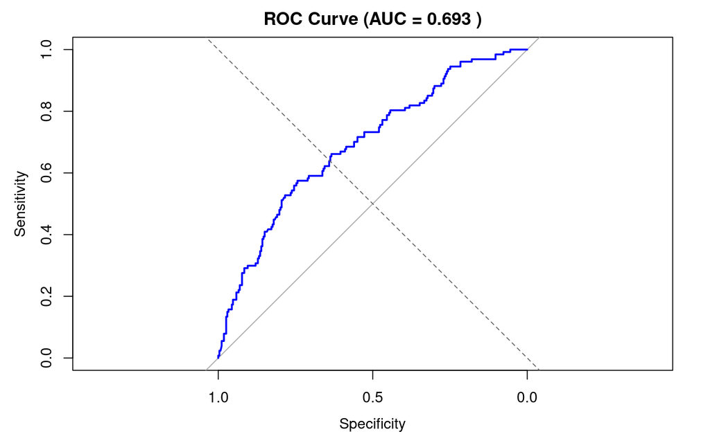

ROC curve for the full logistic regression model.

```r
plot(roc_obj, col = "blue", lwd = 2, main = paste("ROC Curve (AUC =", round(auc_value, 3), ")"))
abline(a = 0, b = 1, lty = 2, col = "gray40")
```

#### 0.0.5.2 Additional Diagnostics

```r
# 1) Multicollinearity diagnostics
vif_values <- vif(model_full)
vif_values
```

```
##          GVIF Df GVIF^(1/(2*Df))
## gre  1.134377  1        1.065071
## gpa  1.155902  1        1.075129
## rank 1.025759  3        1.004248
```

```r
# 2) Deviance residual summary (fit check)
resid_summary <- summary(residuals(model_full, type = "deviance"))
resid_summary
```

```
##    Min. 1st Qu.  Median    Mean 3rd Qu.    Max.
## -1.6268 -0.8662 -0.6388 -0.1061  1.1490  2.0790
```

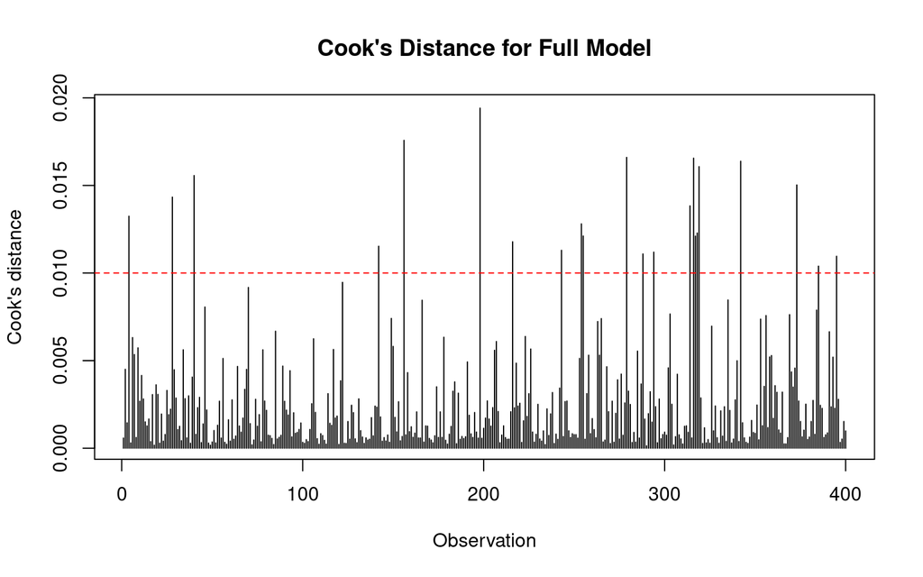

```r
# 3) Influential points via Cook's distance
cooks_d <- cooks.distance(model_full)

plot(
  cooks_d,
  type = "h",
  main = "Cook's Distance for Full Model",
  ylab = "Cook's distance",
  xlab = "Observation"
)
abline(h = 4 / nrow(admissions), col = "red", lty = 2)
```

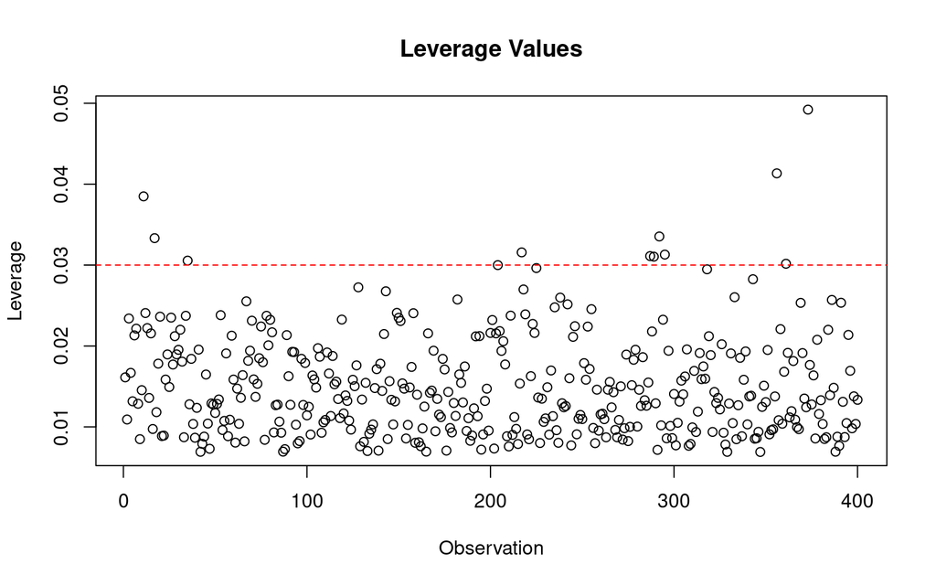

```r
# 4) Leverage diagnostics
plot(
  hatvalues(model_full),
  ylab = "Leverage",
  xlab = "Observation",
  main = "Leverage Values"
)
abline(h = 2 * mean(hatvalues(model_full)), col = "red", lty = 2)
```

### 0.0.6 Conclusions

Based on the EDA and logistic regression models:

1. **GPA and GRE** are positively associated with admission probability.
2. **Institution rank matters**: applicants from lower-tier institutions (higher numeric rank) generally have lower odds of admission relative to top-tier institutions.
3. The **full model** performs better than single-predictor models by combining academic performance and institutional context.
4. Diagnostics indicate the model is reasonably stable and suitable for inference in this assignment context.

Overall, admission appears to be most strongly predicted by a combination of applicant achievement (GPA, GRE) and undergraduate institution rank.